# Assignment 02

Erik Fichter

9/16/2020

## Variables used:

The purpose of my analysis is to draw lines between real estate values and in relation to the distance to work / the commute time. So far, looking at the data I figured out that I might have to use a different approach to see qualitative results. While I can read the value of properties the area is categorical and has a low accuracy so that it is hard to evaluate the value per area. Therefore I might go in the next week for a alternative direction looking at the rent prices instead as they reflect the value of an area in a similar manner. Also it would be required to patch the location of that residency with the same commute data together. Here the variables I used for this exercise:

1. Value of the property (continuous): VALP
2. Amount and type of units within the structure (categorical): BLD
3. Number of bedrooms (continuous): BDSP
4. Travel time to work (continuous): JWMNP
5. Means of transportation (categorical): JWTR

# Distributions and Proportions

## Continuous Variables

```r
ma_re_trans_data<- read.csv("2018 RE Transportation.csv")
options(scipen = 999)
ma_re_trans_data
library(ggplot2)
library(tidyverse)
library(knitr)
```

```r
variables<- data.frame(c("Property_Value","Apartments_in_Structure","Traveltime_to_Work"))

mean<- data.frame(c(mean(ma_re_trans_data$VALP),
                    mean(ma_re_trans_data$BDSP),
                    mean(ma_re_trans_data$JWMNP)))

standard_deviation<- data.frame(c(sd(ma_re_trans_data$VALP),
                          sd(ma_re_trans_data$BDSP),
                          sd(ma_re_trans_data$JWMNP)))

low_CI_95<- data.frame(c(1,1,1))

high_CI_95<- data.frame(c(1,1,1))

IQ_Range<- data.frame(c(IQR(ma_re_trans_data$VALP),
                        IQR(ma_re_trans_data$BDSP),
                        IQR(ma_re_trans_data$JWMNP)))

summary_stats<- data.frame(c(variables,mean,standard_deviation,low_CI_95,high_CI_95,IQ_Range))

colnames(summary_stats)<- c("variable","mean","standard_deviation","low_CI_95","high_CI_95","IQ_Range")

rownames(summary_stats)<- summary_stats$variable

summary_stats<- summary_stats[,2:6]
```

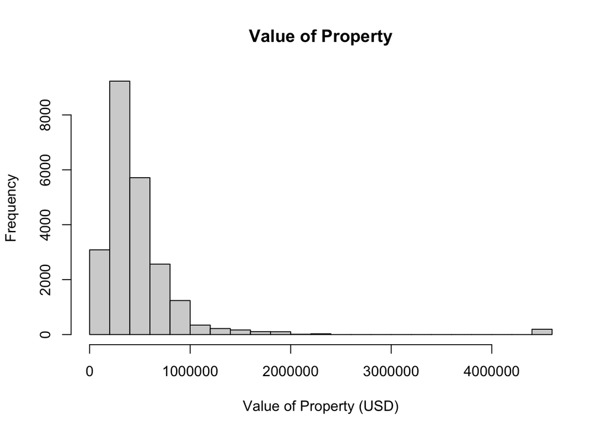

```r
hist(ma_re_trans_data$VALP,
     freq = 1,
     main = "Value of Property",
     xlab = "Value of Property (USD)")
```

[figure not shown]

```r
hist(ma_re_trans_data$BDSP,
     freq = 1,
     main = "Apartments in Structure",
     xlab = "Apartments in Structure")
```

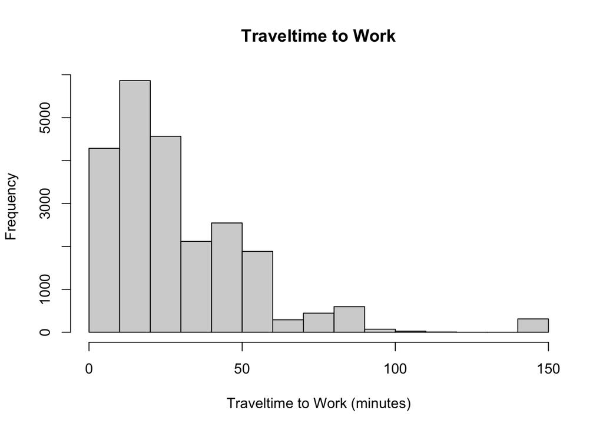

```r
hist(ma_re_trans_data$JWMNP,
     freq = 1,
     main = "Traveltime to Work",
     xlab = "Traveltime to Work (minutes)")
```

```r
summary_stats[1,3:4]<- t.test(ma_re_trans_data$VALP,conf.level = .95)[["conf.int"]]
summary_stats[2,3:4]<- t.test(ma_re_trans_data$BDSP,conf.level = .95)[["conf.int"]]
summary_stats[3,3:4]<- t.test(ma_re_trans_data$JWMNP,conf.level = .95)[["conf.int"]]

print(summary_stats)
```

[output not shown]

```r
attach(ma_re_trans_data)

trans <- unique(JWTR_label)

trans
```

```
##  [1] "Car, truck, or van"
##  [2] "Bus or trolley bus"
##  [3] "Railroad"
##  [4] "Subway or elevated"
##  [5] "Streetcar or trolley car (carro publico in Puerto Rico)"
##  [6] "Walked"
##  [7] "Other method"
##  [8] "Bicycle"
##  [9] "Taxicab"
## [10] "Ferryboat"
## [11] "Motorcycle"
```

```r
car_truck_van <- t.test(JWTR_label == trans[1])
subway <- t.test(JWTR_label == trans[2])
walk <- t.test(JWTR_label == trans[3])
railroad <- t.test(JWTR_label == trans[4])
bus <- t.test(JWTR_label == trans[5])
streetcar <- t.test(JWTR_label == trans[6])
bicycle <- t.test(JWTR_label == trans[7])
other <- t.test(JWTR_label == trans[8])
taxi <- t.test(JWTR_label == trans[9])
ferry <- t.test(JWTR_label == trans[10])
motorcycle <- t.test(JWTR_label == trans[11])

shares <- tibble(trans = c("Car, Truck, or Van",
                             "Subway or elevated train",
                             "Walking",
                             "Railroad",
                             "Bus",
                             "Streetcar or trolley",
                             "Bicycle",
                             "Other mode",
                             "Taxi",
                             "Ferryboat",
                             "Motorcycle"),

                 `Share` = c(car_truck_van$estimate,
                             subway$estimate,
                             walk$estimate,
                             railroad$estimate,
                             bus$estimate,
                             streetcar$estimate,
                             bicycle$estimate,
                             other$estimate,
                             taxi$estimate,
                             ferry$estimate,
                             motorcycle$estimate),

                 Low = c(car_truck_van$conf.int[1],
                             subway$conf.int[1],
                             walk$conf.int[1],
                             railroad$conf.int[1],
                             bus$conf.int[1],
                             streetcar$conf.int[1],
                             bicycle$conf.int[1],
                             other$conf.int[1],
                             taxi$conf.int[1],
                             ferry$conf.int[1],
                             motorcycle$conf.int[1]),

                 High = c(car_truck_van$conf.int[2],
                             subway$conf.int[2],
                             walk$conf.int[2],
                             railroad$conf.int[2],
                             bus$conf.int[2],
                             streetcar$conf.int[2],
                             bicycle$conf.int[2],
                             other$conf.int[2],
                             taxi$conf.int[2],
                             ferry$conf.int[2],
                             motorcycle$conf.int[2]))



knitr::kable(shares, caption = "Proportions and 95-percent confidence intervals")
```

Proportions and 95-percent confidence intervals

[output not shown]

[figure not shown]

```r
ggplot(shares,
       aes(x = reorder(trans, -Share), y = Share, ymin = Low, ymax = High)) +
  geom_bar(stat = "identity") +
  geom_errorbar(width = 0.5) +
  theme_classic() +
  scale_x_discrete(name = "Mode of Transportation") +
  scale_y_continuous(name = "Percent of Population", labels = c("0%", "20%", "40%", "60%", "80%"))
```

```r
attach(ma_re_trans_data)
building <- unique(BLD_label)

building
```

```
##  [1] "One-family house detached" "2 Apartments"
##  [3] "3-4 Apartments"            "5-9 Apartments"
##  [5] "10-19 Apartments"          "50 or more apartments"
##  [7] "One-family house attached" "20-49 Apartments"
##  [9] "Mobile home or trailer"    "Boat, RV, van, etc."
```

```r
one_family_detached <- t.test(BLD_label == building[2])
two_apartments <- t.test(BLD_label == building[1])
three_four_apartments <- t.test(BLD_label == building[3])
five_nine_apartments <- t.test(BLD_label == building[4])
ten_ninteen_apartments <- t.test(BLD_label == building[5])
fity_more_apartments <- t.test(BLD_label == building[6])
one_family_attached <- t.test(BLD_label == building[7])
twenty_fourtynine_apartments <- t.test(BLD_label == building[8])
mobile_home <- t.test(BLD_label == building[9])
boat <- t.test(BLD_label == building[10])

shares <- tibble(building = c("One Family Detached",
                              "One Family Attached",
                             "Mobile Home",
                             "2 Apartments",
                             "3-4 Apartments",
                             "5-9 Apartments",
                             "10-19 Apartments",
                             "20-49 Apartments",
                             "50 + Apartments",
                             "Boat"),

                 `Share` = c(one_family_attached$estimate,
                             one_family_detached$estimate,
                             mobile_home$estimate,
                             two_apartments$estimate,
                             three_four_apartments$estimate,
                             five_nine_apartments$estimate,
                             ten_ninteen_apartments$estimate,
                             twenty_fourtynine_apartments$estimate,
                             fity_more_apartments$estimate,
                             boat$estimate),

                 Low = c(one_family_attached$conf.int[1],
                         one_family_detached$conf.int[1],
                             mobile_home$conf.int[1],
                             two_apartments$conf.int[1],
                             three_four_apartments$conf.int[1],
                             five_nine_apartments$conf.int[1],
                             ten_ninteen_apartments$conf.int[1],
                             twenty_fourtynine_apartments$conf.int[1],
                             fity_more_apartments$conf.int[1],
                         boat$conf.int[1]),

                 High = c(one_family_attached$conf.int[2],
                          one_family_detached$conf.int[2],
                             mobile_home$conf.int[2],
                             two_apartments$conf.int[2],
                             three_four_apartments$conf.int[2],
                             five_nine_apartments$conf.int[2],
                             ten_ninteen_apartments$conf.int[2],
                             twenty_fourtynine_apartments$conf.int[2],
                             fity_more_apartments$conf.int[2],
                          boat$conf.int[2]))




knitr::kable(shares, caption = "Proportions and 95-percent confidence intervals")
```

Proportions and 95-percent confidence intervals

[output not shown]

[figure not shown]

```r
ggplot(shares,
       aes(x = reorder(building, -Share), y = Share, ymin = Low, ymax = High)) +
  geom_bar(stat = "identity") +
  geom_errorbar(width = 0.5) +
  theme_classic() +
  scale_x_discrete(name = "Type of building") +
  scale_y_continuous(name = "Percent of Buildingtype", labels = c("0%", "20%", "40%", "60%", "80%"))
```